```
 Last updated on 30 March, 2022
```

#### Record statistics by species and TCR chain

General statistics. Note that general statistics are computed using the ‘slim’ database version. Slim version, for example, lists the same TCR sequence found in several donors/studies only once and selects representative V/J for a given CDR3aa clonotype and the best score across all redundant records.

| Species | Chain | Records | Paired records | Unique epitopes | Studies |
| --- | --- | --- | --- | --- | --- |
| HomoSapiens | TRA | 28131 | 22100 | 911 | 192 |
| HomoSapiens | TRB | 39740 | 22778 | 1087 | 242 |
| MacacaMulatta | TRA | 74 | 0 | 1 | 1 |
| MacacaMulatta | TRB | 1290 | 0 | 3 | 2 |
| MusMusculus | TRA | 1456 | 1396 | 54 | 34 |
| MusMusculus | TRB | 1971 | 1414 | 62 | 37 |

#### Record statistics by year

Number of unique TCR sequences, epitopes, MHC alleles and studies by **publication** year, cumulative plots.

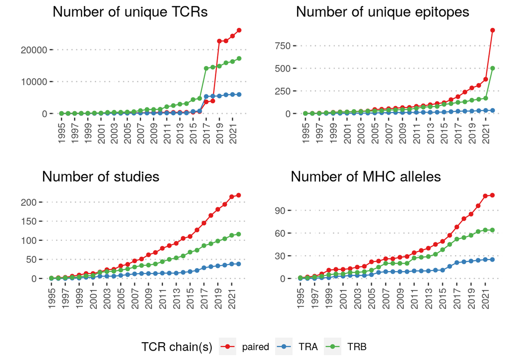

#### Summary by antigen and antigen origin

Representative data for Homo Sapiens

| Parent species | Records | Unique epitopes | Studies |
| --- | --- | --- | --- |
| CMV | 33514 | 31 | 46 |
| InfluenzaA | 8597 | 16 | 23 |
| EBV | 8585 | 30 | 31 |
| SARS-CoV-2 | 6774 | 667 | 14 |
| HomoSapiens | 3969 | 200 | 102 |
| HIV-1 | 2845 | 47 | 31 |
| HCV | 1770 | 15 | 10 |
| YFV | 686 | 1 | 5 |
| HTLV-1 | 220 | 8 | 9 |
| DENV1 | 173 | 1 | 1 |
| DENV3/4 | 166 | 1 | 1 |
| HIV | 149 | 4 | 1 |
| HSV-2 | 69 | 1 | 1 |
| synthetic | 64 | 30 | 5 |
| M.tuberculosis | 61 | 11 | 3 |
| DENV2 | 60 | 1 | 1 |
| TriticumAestivum | 49 | 10 | 6 |
| HCoV-HKU1 | 48 | 1 | 1 |
| HPV | 28 | 1 | 1 |
| MCPyV | 12 | 2 | 1 |
| Homo sapiens | 8 | 4 | 2 |
| StreptomycesKanamyceticus | 6 | 1 | 1 |
| E.Coli | 4 | 2 | 2 |
| HIV1 | 4 | 2 | 1 |
| HHV | 2 | 1 | 1 |
| PseudomonasAeruginosa | 2 | 1 | 1 |
| PseudomonasFluorescens | 2 | 1 | 1 |
| SaccharomycesCerevisiae | 2 | 1 | 1 |
| SelaginellaMoellendorffii | 2 | 1 | 1 |

#### **COVID-19** data

Summary of antigens and T-cell receptors related to COVID-19 pandemic. Number of records for SARS-CoV-2 epitopes grouped by Gene+HLA plotted using alluvium plot. Epitopes with less than 10 records in total were not counted.

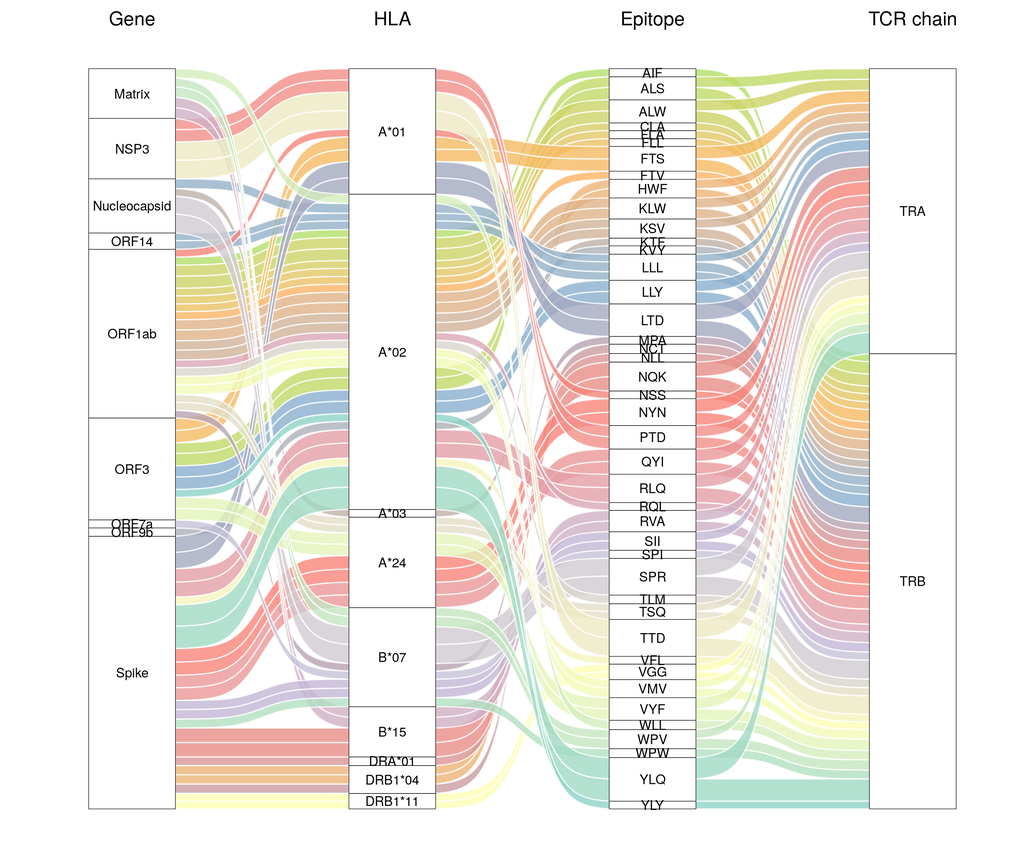

Summary of SARS-CoV-2 epitopes and corresponding TCR alpha and beta chain specificity records

| Gene | HLA | Epitope | Studies | TRA | TRB |
| --- | --- | --- | --- | --- | --- |
| Spike | HLA-A*02 | YLQPRTFLL | 7 | 587 | 749 |
| NSP3 | HLA-A*01 | TTDPSFLGRY | 1 | 243 | 244 |
| Nucleocapsid | HLA-B*07 | SPRWYFYYL | 3 | 201 | 282 |
| Spike | HLA-A*01 | LTDEMIAQY | 2 | 125 | 129 |
| Spike | HLA-B*15 | NQKLIANQF | 1 | 75 | 73 |
| Spike | HLA-A*02 | RLQSLQTYV | 4 | 53 | 88 |
| Spike | HLA-A*24 | NYNYLYRLF | 3 | 56 | 52 |
| Spike | HLA-A*24 | QYIKWPWYI | 3 | 42 | 44 |
| ORF3 | HLA-A*01 | FTSDYYQLY | 2 | 41 | 40 |
| ORF3 | HLA-A*02 | LLYDANYFL | 3 | 28 | 41 |
| NSP3 | HLA-A*01 | PTDNYITTY | 2 | 29 | 38 |
| ORF3 | HLA-A*02 | ALSKGVHFV | 3 | 24 | 40 |
| ORF1ab | HLA-A*02 | ALWEIQQVV | 2 | 27 | 36 |
| ORF3 | HLA-A*24 | VYFLQSINF | 2 | 29 | 29 |
| Matrix | HLA-B*15 | RVAGDSGFAAY | 1 | 24 | 24 |
| ORF1ab | HLA-A*02 | KLWAQCVQL | 1 | 21 | 25 |
| Matrix | HLA-B*07 | WPVTLACFV | 1 | 14 | 21 |
| ORF1ab | HLA-A*02 | KSVNITFEL | 1 | 16 | 19 |
| Spike | HLA-B*07 | SIIAYTMSL | 1 | 15 | 17 |
| Spike | HLA-DRB1*04 | HWFVTQRNFYEPQII | 1 | 16 | 16 |
| ORF1ab | HLA-A*02 | VMVELVAEL | 1 | 13 | 17 |
| Matrix | HLA-A*02 | WLLWPVTLA | 1 | 9 | 16 |
| ORF14 | HLA-A*02 | LLLEWLAMA | 1 | 10 | 13 |
| Nucleocapsid | HLA-A*02 | LLLDRLNQL | 2 | 4 | 18 |
| ORF1ab | HLA-A*02 | TLMNVLTLV | 1 | 9 | 13 |
| Spike | HLA-DRB1*04 | NCTFEYVSQPFLMDL | 1 | 6 | 16 |
| ORF1ab | HLA-A*24 | TSQWLTNIF | 1 | 10 | 11 |
| ORF9b | HLA-A*02 | KVYPIILRL | 1 | 9 | 12 |
| Spike | HLA-B*07 | WPWYIWLGF | 1 | 7 | 14 |
| Spike | HLA-DRB1*11 | VGGNYNYLYRLFRKS | 1 | 10 | 10 |

[output cut: 650 more lines]

#### Distribution VDJdb confidence scores

Legend: 0 - low confidence, 1 - medium confidence, 2 - high confidence, 3 - very high confidence.

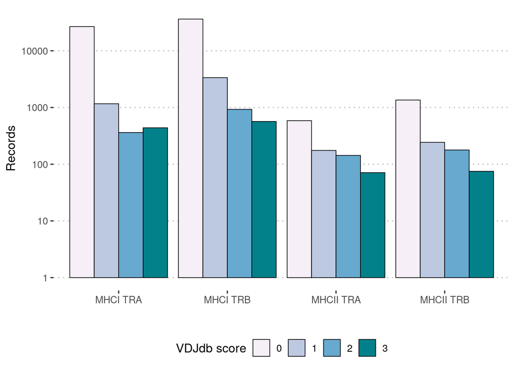

#### Spectratype

Representative data for Homo Sapiens. The spectratype is colored by epitope.

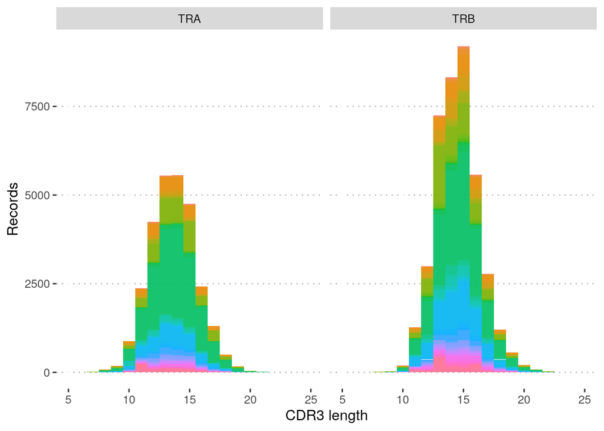

#### V(D)J usage and MHC alleles

Representative data for Homo Sapiens, Variable gene. Only Variable genes and MHC alleles with at least 10 records are shown.

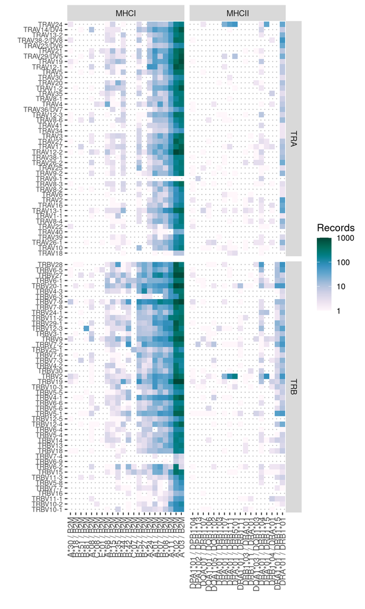

Zoom-in for correspondence between human TRBV genes and MHC class I alleles for links supported by more than 50 records.

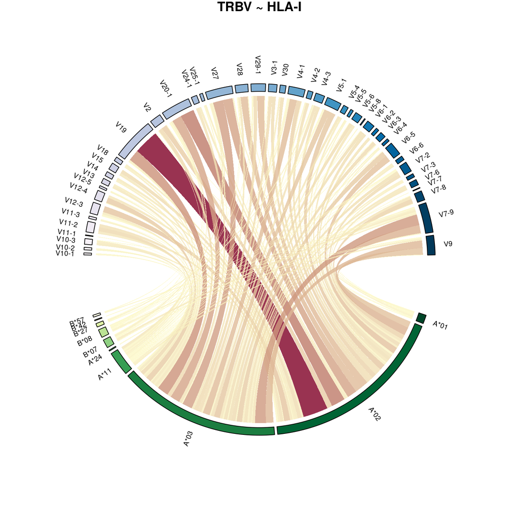

#### Detailed summary for HLA

Representative data for Homo Sapiens MHC class I and II

| First chain | Second chain | Records | Unique epitopes | Studies |
| --- | --- | --- | --- | --- |
| HLA-A*03 | B2M | 25618 | 17 | 12 |
| HLA-A*02 | B2M | 24804 | 565 | 132 |
| HLA-A*11 | B2M | 4765 | 10 | 9 |
| HLA-A*01 | B2M | 2020 | 119 | 15 |
| HLA-B*07 | B2M | 1999 | 119 | 25 |
| HLA-B*08 | B2M | 1993 | 14 | 20 |
| HLA-DRA*01 | HLA-DRB1*01 | 1259 | 15 | 12 |
| HLA-A*24 | B2M | 798 | 71 | 13 |
| HLA-B*57 | B2M | 732 | 9 | 9 |
| HLA-B*27 | B2M | 654 | 4 | 10 |
| HLA-B*42 | B2M | 334 | 6 | 4 |
| HLA-DRA1*01 | HLA-DRB1*15 | 306 | 1 | 1 |
| HLA-B*44 | B2M | 293 | 9 | 7 |
| HLA-B*35 | B2M | 286 | 21 | 19 |
| HLA-DRA*01 | HLA-DRB5*01 | 283 | 4 | 5 |
| HLA-DRA*01 | HLA-DRB1*04 | 282 | 7 | 7 |
| HLA-B*15 | B2M | 233 | 6 | 4 |
| HLA-A*68 | B2M | 208 | 3 | 3 |
| HLA-DRA*01 | HLA-DRB1*11 | 172 | 4 | 5 |
| HLA-DRA*01 | HLA-DRB1*15 | 144 | 6 | 7 |
| HLA-A*08 | B2M | 117 | 1 | 1 |
| HLA-DRA*01 | HLA-DRB1*07 | 74 | 5 | 5 |
| HLA-DRB1*04 | HLA-DRA*01 | 54 | 2 | 1 |
| HLA-B*81 | B2M | 48 | 1 | 2 |
| HLA-C*07 | B2M | 43 | 3 | 2 |
| HLA-DQA1*05 | HLA-DQB1*02 | 39 | 8 | 4 |
| HLA-A*30 | B2M | 35 | 3 | 2 |
| HLA-DRB1*03 | HLA-DRA*01 | 32 | 3 | 1 |
| HLA-DPA1*01 | HLA-DPB1*04 | 30 | 8 | 1 |
| HLA-DRA1*01 | HLA-DRB1*11 | 30 | 1 | 1 |
| HLA-B*51 | B2M | 29 | 1 | 1 |
| HLA-DQA*01 | HLA-DRB1*07 | 29 | 1 | 1 |
| HLA-DQA1*01 | HLA-DQB1*06 | 29 | 5 | 5 |
| HLA-DQA1*03 | HLA-DQB1*03 | 26 | 7 | 7 |
| HLA-DRB1*11 | HLA-DRA*01 | 20 | 1 | 1 |
| HLA-DPA1*02 | HLA-DPB1*13 | 16 | 1 | 1 |
| HLA-E*01 | B2M | 16 | 7 | 3 |
| HLA-C*08 | B2M | 14 | 3 | 4 |
| HLA-B*18 | B2M | 13 | 5 | 2 |
| HLA-DRA*01 | HLA-DRB1*03 | 10 | 2 | 2 |
| HLA-B*38 | B2M | 9 | 4 | 2 |
| HLA-B*53 | B2M | 9 | 1 | 1 |
| HLA-DQA1*05 | HLA-DQB1*03 | 9 | 4 | 2 |
| HLA-DRA*01 | HLA-DRB3*03 | 9 | 3 | 3 |
| HLA-DQA1*01 | HLA-DQB1*05 | 8 | 4 | 3 |
| HLA-A*29 | B2M | 6 | 3 | 1 |
| HLA-B*40 | B2M | 4 | 2 | 1 |
| HLA-C*01 | B2M | 4 | 1 | 1 |
| HLA-C*03 | B2M | 4 | 2 | 2 |
| HLA-DPA1*01 | HLA-DPB1*02 | 4 | 2 | 2 |
| HLA-DQA1*02 | HLA-DQB1*02 | 4 | 1 | 1 |
| HLA-DRA*01 | HLA-DRB3*02 | 4 | 1 | 1 |
| HLA-DRB1*07 | HLA-DRA*01 | 3 | 1 | 1 |
| HLA-A*25 | B2M | 2 | 1 | 1 |
| HLA-B*12 | B2M | 2 | 1 | 1 |
| HLA-B*37 | B2M | 2 | 1 | 1 |
| HLA-B*58 | B2M | 2 | 1 | 1 |
| HLA-C*05 | B2M | 2 | 1 | 1 |
| HLA-C*06 | B2M | 2 | 1 | 1 |
| HLA-C*14 | B2M | 2 | 1 | 1 |
| HLA-DPA1*01 | HLA-DPB1*03 | 2 | 1 | 1 |
| HLA-DRA*01 | HLA-DRB1*09 | 2 | 1 | 1 |
| HLA-DRA*01 | HLA-DRB1*13 | 2 | 1 | 1 |
| HLA-A*32 | B2M | 1 | 1 | 1 |
| HLA-B*14 | B2M | 1 | 1 | 1 |
| HLA-B*52 | B2M | 1 | 1 | 1 |
| HLA-C*04 | B2M | 1 | 1 | 1 |